# Merge-GroupBy slides

## 复习：关系代数

- 一切都是表，可以表达一切数据
  - 未必真实存在，可以是逻辑的表
- 集合运算，交、并、差
- 线性运算，笛卡尔积、投影、选取
- 关系运算，连接
- 拓展运算，GroupBy（分组）

### 困惑：以代数理论组织数据够图灵奖？

- Edgar F. Codd，1981年图灵奖得主

  Relational database: a practical foundation for productivity.
- Michael Stonebraker 2014年图灵奖得主

  For fundamental contributions to the concepts and practices underlying modern database systems.
- （外行的视角）如此简明的理论为何影响深远？
  1. 数据组织在物理学家眼里，是一件微不足道的“小事”：如何组织都无所谓，能用就行
  2. “自然”地采用树状结构：一个高能量的粒子产生很多“次数粒子”，次数粒子诱导出光子，一个光子被放大成１千万个电子
  3. 争论：什么样的“树”最好？
     - 身分 vs. 能力：出身星系 vs. 天体种类
     - 身分 vs. 能力：母粒子 vs. 粒子种类
  4. 每个人有自己关注的物理问题，因此争证持续，或者走向分裂
  5. “都是那些个二货坚持用奇怪的数据格式”
  6. 反思时，发现自己在“小事”上花了太多精力，非常空虚

### 研究这个问题是为了不再研究这个问题

- 按照简明的理论组织数据，从此之后忘掉它。
- 简明的理论有严格的数学体系
- 与正则表达式一样，可以有完美的社会分工
  - 使用者以关系代数的思想和语言描绘出自己要做什么
  - 研发者以天才的程序技巧实现关系代数的基本运算，优化复合运算

### 某些反弹

- 2000年左右，Web 界开始了去“关系数据库”的运动，开发 NoSQL 服务。
  - SQL 是 structured query language，关系数据库的基本语言
  - 关系数据库是以关系代数为基础的数据管理程序，有严格的数据规范
- NoSQL 运动的支持者认为，世界丰富多样，不应该受关系代数的限制。
  - Web 2.0 被作为商业概念炒作，从业人员四处革命
  - 关系代数让一切都成为了表格，大大限制了我们的想象力，剥夺了我们自由设计数据格式的权力
  - 于是大家开浪起来，进行了一轮新的探索，在这个过程中创造了一批卓越的分布式的数据系统
  - Google 的 MapReduce 也在此运动中，改变了整个大数据处理的格局。
- 但是，随着时间的推移，这些 NoSQL 的方案逐渐成熟，慢慢发展出关系代数的各种运算
  - 关系代数系统被重新发明一次，与分布式系统结合起来，成为数据时代的基石

## 连接

- 以公共列为媒介，把两个表连成一个表

```r
A <- data.frame(ID=c(1,2), name=c("Wang", "Li"), GPA=c(3, 4))
A
```

| ID | name | GPA |
| --- | --- | --- |
| 1 | Wang | 3 |
| 2 | Li | 4 |

```r
B <- data.frame(ID=c(2,3), name=c("Li", "Zhang"), age=c(19, 20))
B
```

| ID | name | age |
| --- | --- | --- |
| 2 | Li | 19 |
| 3 | Zhang | 20 |

```r
# 内连接
merge(A, B)
```

| ID | name | GPA | age |
| --- | --- | --- | --- |
| 2 | Li | 4 | 19 |

```r
# 左连接
merge(A, B, all.x=TRUE)
```

| ID | name | GPA | age |
| --- | --- | --- | --- |
| 1 | Wang | 3 | NA |
| 2 | Li | 4 | 19 |

```r
# 右连接
merge(A, B, all.y=TRUE)
```

| ID | name | GPA | age |
| --- | --- | --- | --- |
| 2 | Li | 4 | 19 |
| 3 | Zhang | NA | 20 |

```r
# 外连接
merge(A, B, all=TRUE)
```

| ID | name | GPA | age |
| --- | --- | --- | --- |
| 1 | Wang | 3 | NA |
| 2 | Li | 4 | 19 |
| 3 | Zhang | NA | 20 |

## 关系代数之外的常用运算

- GroupBy, SortBy

```r
require(dplyr)
AxB <- merge(A, B, by=NULL)
```

```r
AxB %>% group_by(name.x) %>% summarise(n=n())
```

| name.x | n |
| --- | --- |
| Li | 2 |
| Wang | 2 |

```r
# SortBy 即 DataFrame 按列排序
order(AxB$name.x)
```

1. 2

2. 4

3. 1

4. 3

```r
AxB[order(AxB$name.x),]
```

|  | ID.x | name.x | GPA | ID.y | name.y | age |
| --- | --- | --- | --- | --- | --- | --- |
| 2 | 2 | Li | 4 | 2 | Li | 19 |
| 4 | 2 | Li | 4 | 3 | Zhang | 20 |
| 1 | 1 | Wang | 3 | 2 | Li | 19 |
| 3 | 1 | Wang | 3 | 3 | Zhang | 20 |

## 课堂练习：成绩录入

天才少年爱迪生上课时做了一个梦，梦见自己成为了一门课的助教，协助老师向注册中心系统录成绩。但是少年爱迪生在梦境位面中的超能力减半，无法调用他强大的编程战斗值，所以他找到了你。

```r
classes <- read.csv("classes.csv")
print(classes)
```

```
     班级 院系
1    核71 工物
2  工物61 工物
3  工物72 工物
4  基科71 物理
5  物理72 物理
6  物理71 物理
7  工物73 工物
8  工物83 工物
9  工物71 工物
10 工物70 工物
11 基科72 物理
```

```r
students <- read.csv("name_list-practice.csv")
print(head(students))
```

```
  学号 姓名 性别   班级    联系方式
1    1   AB   女 物理71 50626922811
2    2   AC   女 工物61  6533879773
3    3   AD   男 物理71 43865400582
4    4   AE   男 工物71 58581462691
5    5   AF   女 物理72 45017508911
6    6   AG   男 工物72 26000243873
```

```r
scores <- read.csv("score-practice.csv")
print(head(scores))
```

```
  学号 self.intro a.b rank.guesser hdf5 prime heart.curve gpa.calculator
1    1        100 100          100  100   100         120            113
2    2        100 100           98  100   100         103            108
3    3        100 100          100  100   100         120             19
4    4        100 100          102  100   100         108            105
5    5        100 100          100  100   100         103            104
6    6        100 100           98    0    56         100             70
  curve.fitting 大作业
1            78  128.7
2            32   90.0
3            94  115.0
4            97  124.3
5            76  115.5
6             0    0.0
```

### 少年爱迪生想

- 比较物理系和工物系的男女比例
- 算出大家的总评成绩：
  - 小作业权相等，总体占 70% 的成绩
  - 大作业占 30% 的成绩
  - 划分出不同的分数段，给出某分数段同学的手机号
- 画出各班平均小作业成绩的变化曲线

## GGPlot

- Grammer of Graphics plot
- 绘图的语言，每个维度都由一个变量决定：
  1. x 轴
  2. y 轴
  3. 颜色
  4. 标记的形状
  5. 子图

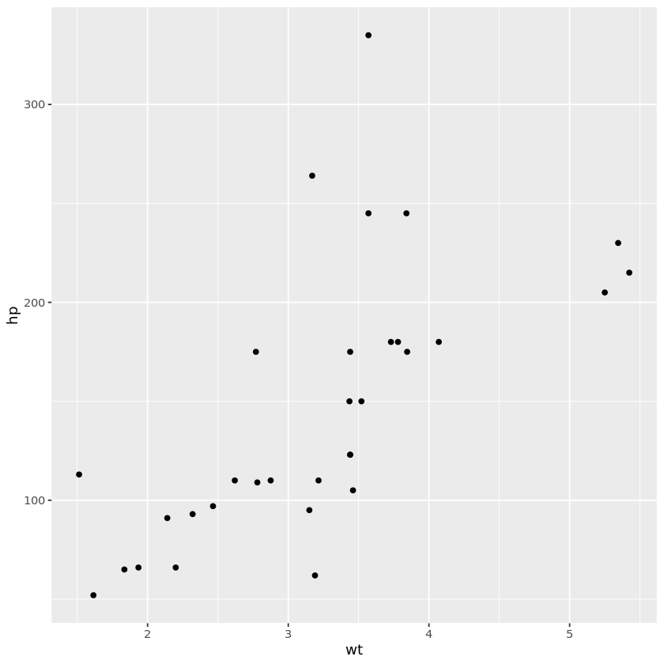

```r
require(ggplot2)
data(mtcars)
p <- ggplot(mtcars, aes(x=wt, y=hp)) + geom_point()
print(p)
```

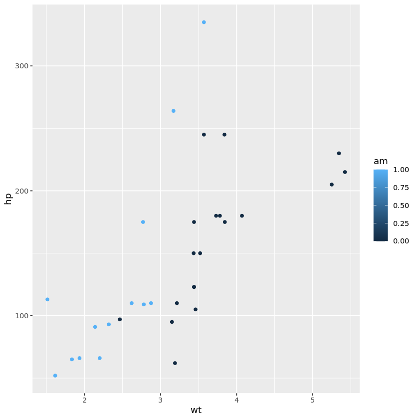

```r
p <- p + aes(color=am)
print(p)
```

```r
mtcars$am <- factor(mtcars$am, levels=c(0, 1), labels=c("automatic", "manual"))
```

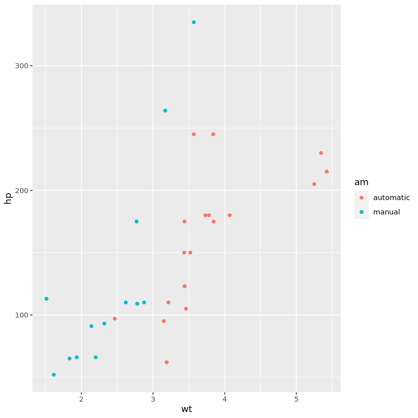

```r
p <- p %+% mtcars
print(p)
```

## SQL 语言

- 关系代数的天然语言，语法简明
  - 描述型的语言，描述把什么样的数据取出来
  - 也可以写数据，但一般是一次写，多次读
- 关系代数最典型的实现是关系数据库 (Relational Database)，一般使用 SQL 语言描述
  - Oracle（甲骨文）公司数据库
  - MariaDB (MySQL 的后继)
  - PostgreSQL
  - SQLite
- 另一个分支是统计软件，比如 S 语言中的 SAS/SPSS 中的 Dataset 或 DataFrame
  - GNU R 以及对应的 R 语言，是一个 S 语言的后继，其中 DataFrame 是语言的核心
  - Pandas 受 GNU R 的影响，目标是在 Python 的语言环境中实现 DataFrame 及其基本操作
- MapReduce 分布式大数据算法也受到关系代数的影响，一般都会使用关系代数作为平台高级接口
  - Hadoop 生态圈, Spark, etc.

### Ｒ 的 SQLite 库

- 安装 RSQLite

  ```
  apt install r-cran-rsqlite r-cran-dbi
  ```

```r
require(DBI)
db <- dbConnect(RSQLite::SQLite(), "credits.sqlite")
```

### 写入数据

- Data Frame 与数据库的结构一样，可以直接写。

```r
dbWriteTable(db, "classes", classes)
dbWriteTable(db, "scores", scores)
dbWriteTable(db, "students", students)
dbListTables(db)
```

1. 'classes'

2. 'scores'

3. 'students'

### 读出数据

```r
dbGetQuery(db, 'SELECT * FROM classes')
```

| 班级 | 院系 |
| --- | --- |
| 核71 | 工物 |
| 工物61 | 工物 |
| 工物72 | 工物 |
| 基科71 | 物理 |
| 物理72 | 物理 |
| 物理71 | 物理 |
| 工物73 | 工物 |
| 工物83 | 工物 |
| 工物71 | 工物 |
| 工物70 | 工物 |
| 基科72 | 物理 |

```r
dbGetQuery(db, 'SELECT * FROM students LIMIT 7')
```

| 学号 | 姓名 | 性别 | 班级 | 联系方式 |
| --- | --- | --- | --- | --- |
| 1 | AB | 女 | 物理71 | 50626922811 |
| 2 | AC | 女 | 工物61 | 6533879773 |
| 3 | AD | 男 | 物理71 | 43865400582 |
| 4 | AE | 男 | 工物71 | 58581462691 |
| 5 | AF | 女 | 物理72 | 45017508911 |
| 6 | AG | 男 | 工物72 | 26000243873 |
| 7 | AH | 男 | 物理71 | 4295424729 |

```r
dbGetQuery(db, 'SELECT 班级 FROM students where 性别="女"')
```

| 班级 |
| --- |
| 物理71 |
| 工物61 |
| 物理72 |
| 核71 |
| 基科72 |
| 物理71 |
| 基科72 |
| 核71 |
| 基科71 |
| 物理72 |
| 工物70 |
| 物理71 |
| 基科72 |
| 物理72 |

```r
dbGetQuery(db, 'SELECT students.姓名, classes.院系 FROM students INNER JOIN classes ON students.班级 == classes.班级 LIMIT 10')
```

| 姓名 | 院系 |
| --- | --- |
| AB | 物理 |
| AC | 工物 |
| AD | 物理 |
| AE | 工物 |
| AF | 物理 |
| AG | 工物 |
| AH | 物理 |
| AI | 工物 |
| AJ | 工物 |
| AK | 物理 |

## SQL 的基本运算

- 交、并、差
- 笛卡尔积、投影、选取
- 连接、GroupBy